# 13 Data annotation

Author

Affiliation

Vladimir Buskin

Catholic University of Eichstätt-Ingolstadt

## 13.1 Recommended reading

> S. T. Gries (2013): Chapter 1.3.3

## 13.2 Sample study

### 13.2.1 Theoretical background

Let’s assume we are interested in the object realisation patterns of the verb *eat* in the British ICE component. A quick review of the literature tells us that …

- … argument realisation may be related to the aspectual structure of a verbal action (cf. Goldberg 2001), but …
- … there is a stronger focus on situation aspect (telicity/atelicity; i.e., logical endpoints of actions) than on grammatical aspect (i.e., perfective/progressive).

Since grammatical aspect is also concerned with the temporal construal of actions, it raises the question of whether or not it can also influence object realisation. To investigate the relationship between aspect and object realisation, we will perform an exemplary analysis on the verb lemma EAT.

### 13.2.2 Obtaining data

We load all necessary libraries to query the ICE-GB corpus and run a KWIC-search using the regular expression `\\b(eat(s|ing|en)?|ate)\\b`, which finds all inflection forms of EAT. We then store the results in a spreadsheet file `kwic_eat.xlsx`.

```r
# Load library and corpus
library(quanteda)
library(writexl)

ICE_GB <- readRDS("ICE_GB.RDS")

# Perform query
kwic_eat <- kwic(ICE_GB,
          phrase("\\b(eat(s|ing|en)?|ate)\\b"),
          valuetype = "regex",
          window = 15)

# Store results
write_xlsx(kwic_eat, "kwic_eat.xlsx")
```

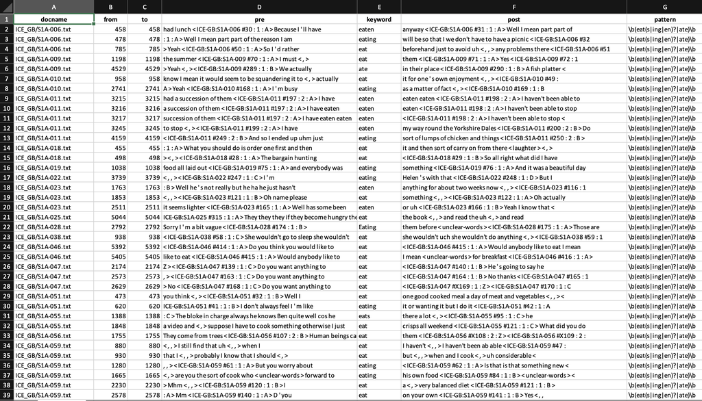

## 13.3 Data annotation

Whenever you decide to work on your corpus results, it is good practice to duplicate your file and append the current date to the filename. Re-save it as, for instance, `kwic_eat_09_09_2024.xlsx` and open it again. This way you’re performing basic **version control**, which will allow you to return to previous stages of your analysis with ease.

**Naming variables**

Now, you are ready to annotate your data! An easy coding scheme would involve classifying rows where *eat* occurs with an object as `yes`. Conversely, rows where the direct object is not realised syntactically are assigned the column value `no`. In the aspect column, verbal aspect will be coded as either `perfective`, `progressive` or `neutral`, following S. Gries and Deshors (2014): 118.

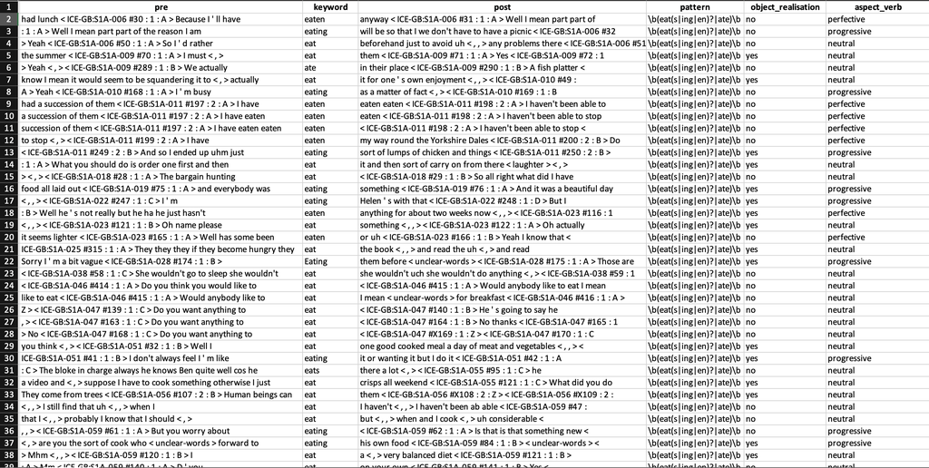

### 13.3.1 Dealing with problematic cases

However, things are not always that clear-cut. What if you encounter a false positive, i.e., an erroneous hit in your dataset? Further down in the spreadsheet the keyword *ate* is actually part of the preceding word, *inappropriate*.

|  | docname | from | to | pre | keyword | post | pattern |
| --- | --- | --- | --- | --- | --- | --- | --- |
| 113 | ICE_GB/W2F-019.txt | 696 | 696 | : 1 > Too much colour on her face would be inappropri < l > | ate | , she feels , but she wears a light foundation . < ICE-GB:W2F-019 #28 : | \b(eat(s\|ing\|en)?\|ate)\b |

**What do I do with false hits?**

Short answer: Do **not** delete irrelevant rows or columns. Essentially, from the moment you’ve obtained your corpus output, you should withstand the temptation to delete anything from it. Instead, adopt the practice of indicating missing values or irrelevant rows by an `NA` in a separate column. In later analyses, these can be easily filtered out!

This also minimises the risk of accidentally getting rid of data that could have proven important at a later point in time.

### 13.3.2 Getting the data back into R

Import the Excel file via

```r
# Load library
library(readxl)

# Read file contents into the variable "kwic_data"
kwic_data <- read_xlsx("kwic_eat_09_09_2024.xlsx")

# Print the first six lines of "kwic_data"
print(head(kwic_data))
```

```
# A tibble: 6 × 9
  docname  from    to pre   keyword post  pattern object_realisation aspect_verb
  <chr>   <dbl> <dbl> <chr> <chr>   <chr> <chr>   <chr>              <chr>
1 ICE_GB…   458   458 had … eaten   anyw… "\\b(e… no                 perfective
2 ICE_GB…   478   478 : 1 … eating  will… "\\b(e… no                 progressive
3 ICE_GB…   785   785 > Ye… eat     befo… "\\b(e… no                 neutral
4 ICE_GB…  1198  1198 the … eat     them… "\\b(e… yes                neutral
5 ICE_GB…  4529  4529 > Ye… ate     in t… "\\b(e… no                 neutral
6 ICE_GB…   958   958 know… eat     it f… "\\b(e… yes                neutral
```

### 13.3.3 Adding a case list

S. T. Gries (2013) recommends setting up the first column of the data frame such that it “numbers all n cases from $1$ to $n$ so that every row can be uniquely identified and so that you always restore one particular ordering (e.g., the original one)” (S. T. Gries 2013: 26). This is very easy to do: We specify a numeric vector ranging from 1 to the total number of rows in the data frame.

```r
# Create a new Case column (which, by default, is moved to the very end of the data frame)
kwic_data$Case <- 1:nrow(kwic_data)

# Move the Case column to the front of the data frame
library(tidyverse)

kwic_data <- relocate(kwic_data, Case)

# Print reordered data frame
print(head(kwic_data))
```

```
# A tibble: 6 × 10
   Case docname        from    to pre   keyword post  pattern object_realisation
  <int> <chr>         <dbl> <dbl> <chr> <chr>   <chr> <chr>   <chr>
1     1 ICE_GB/S1A-0…   458   458 had … eaten   anyw… "\\b(e… no
2     2 ICE_GB/S1A-0…   478   478 : 1 … eating  will… "\\b(e… no
3     3 ICE_GB/S1A-0…   785   785 > Ye… eat     befo… "\\b(e… no
4     4 ICE_GB/S1A-0…  1198  1198 the … eat     them… "\\b(e… yes
5     5 ICE_GB/S1A-0…  4529  4529 > Ye… ate     in t… "\\b(e… no
6     6 ICE_GB/S1A-0…   958   958 know… eat     it f… "\\b(e… yes
# ℹ 1 more variable: aspect_verb <chr>
```

## 13.4 Where do I go from here?

As soon as you’ve fully annotated your dataset and reviewed it for potential coding errors, the next step involves analysing your data **statistically** to uncover potential patterns that are not visible to the naked eye. These patterns can include (subtle to major) differences in frequency of occurrence, relationships with other linguistically relevant features (e.g., register/genre) or probabilities (e.g., the probability that an object is omitted), among many others. The following units offer an introduction to statistics, where “statistics” is best understood as “a collection of methods which help us to describe, summarize, interpret, and analyse data” (Heumann, Schomaker, and Shalabh 2022).

Goldberg, Adele E. 2001. “Patient Arguments of Causative Verbs Can Be Omitted: The Role of Information Structure in Argument Distribution.” *Language Sciences* 23 (4): 503–24.

Gries, Stefan Thomas. 2013. *Statistics for Linguistics with r: A Practical Introduction*. 2nd rev. ed. Berlin; Boston: De Gruyter Mouton.

Gries, Stefan, and Sandra Deshors. 2014. “Using Regressions to Explore Deviations Between Interlanguage and Native Language.” *Corpora* 9: 109–36.

Heumann, Christian, Michael Schomaker, and Shalabh. 2022. *Introduction to Statistics and Data Analysis: With Exercises, Solutions and Applications in r*. 2nd ed. Cham: Springer. https://doi.org/10.1007/978-3-031-11833-3.